# ACTG175 Binary Benefi Search: Simulation Study

**Setup and parameters (click to expand)**

```r
library(forestsearch)
library(speff2trial)
```

**Setup and parameters (click to expand)**

```r
library(data.table)
library(gt)
library(ggplot2)
library(doFuture)
```

**Setup and parameters (click to expand)**

```r
library(foreach)

set.seed(8316951L)

# -- Simulation control --------------------------------------------------------
nsims_alt   <- 20L
nsims_null  <- 20L
n_workers   <- max(1L, floor(0.95 * parallel::detectCores(logical = FALSE)))
sim_n       <- 1000L

# -- FS parameters -------------------------------------------------------------
c1 <- round(1/0.5,3)           # hr.threshold (OR scale)
c2 <- round(1/0.75,3)            # hr.consistency
fs_pconsistency    <- 0.80
fs_splits          <- 1000L
fs_n_min           <- 60L
fs_d0_min          <- 10L
fs_d1_min          <- 10L
fs_maxk            <- 2L
fs_dmin_grf        <- 0.0
fs_seedit          <- 8316951L
fs_sg_focus        <- "maxSG"
fs_use_lasso       <- FALSE
fs_use_grf         <- TRUE
fs_return_selected_cuts_only <- FALSE
fs_is_rct          <- TRUE

# -- GRF standalone parameters ------------------------------------------------
grf_dmin           <- 0.10
grf_maxdepth       <- 2L
grf_sg_criterion   <- "mDiff"

# -- Reporting -----------------------------------------------------------------
sg_notation        <- "benefit"

# -- Calibration ---------------------------------------------------------------
cal_target_or      <- 4.0

# -- Diagnostic capture --------------------------------------------------------
diag_keep          <- c("fs_full", "candidate_table")
diag_keep_first_n  <- 5L

# -- Plot thresholds -----------------------------------------------------------
sgdist_min_pct_alt  <- 1
sgdist_min_pct_null <- 1
sgdist_top_k        <- 10L
ordist_ylim         <- c(0, 6)
```

# 1 Data Preparation

**ACTG175 data prep (click to expand)**

```r
# ACTG175: arm 1 = ZDV+ddI (experimental), arm 3 = ddI (control)
actg_df <- subset(speff2trial::ACTG175, arms %in% c(1L, 3L))
actg_df$id <- seq_len(nrow(actg_df))

# Treatment: ZDV+ddI = 1, ddI = 0 (NO switching)

# Here we switch
actg_df$treat <- 1-ifelse(actg_df$arms == 1L, 1L, 0L)

# Binary outcome: adverse (failure to improve)
actg_df$y_binary <- as.integer(actg_df$cd420 <= actg_df$cd40)
actg_df <- actg_df[!is.na(actg_df$cd420), ]

# -- DGM factor variables -----------------------------------------------------
# z1, z2: TRUE subgroup Q = {cd40 > 421 & wtkg > 82.3}
# (from observed-data FS result — see companion analysis document)
actg_df$z1  <- as.factor(ifelse(actg_df$cd40 > 421, 1L, 0L))
actg_df$z2  <- as.factor(ifelse(actg_df$wtkg > 82.3, 1L, 0L))

# z7-z12: truly binary indicators (no continuous counterpart)
actg_df$z7  <- as.factor(actg_df$hemo)
actg_df$z8  <- as.factor(actg_df$homo)
actg_df$z9  <- as.factor(actg_df$drugs)
actg_df$z10 <- as.factor(actg_df$race)
actg_df$z11 <- as.factor(actg_df$gender)
actg_df$z12 <- as.factor(actg_df$symptom)

actg_df$flag_harm_ref <- as.integer(actg_df$z1 == 1 & actg_df$z2 == 1)

# -- Analysis covariates (what the analyst sees) -------------------------------
cont_vars <- c("age", "preanti", "wtkg", "karnof", "cd40", "cd80")
bin_vars  <- c("hemo", "homo", "drugs", "race", "gender", "symptom")
for (v in bin_vars) actg_df[[v]] <- as.factor(actg_df[[v]])
confounders <- c(cont_vars, bin_vars)

# -- DGM variable sets ---------------------------------------------------------
dgm_factor_vars   <- c("z1", "z2", paste0("z", 7:12))
dgm_cont_vars     <- cont_vars
dgm_subgroup_vars <- c("z1", "z2")
dgm_subgroup_cuts <- list(z1 = 1L, z2 = 1L)

# -- Summary -------------------------------------------------------------------
Q_n   <- sum(actg_df$flag_harm_ref)
Q_N   <- nrow(actg_df)
Q_pct <- 100 * Q_n / Q_N

cat(sprintf("N = %d, Q prevalence = %d / %d (%.1f%%)\n", Q_N, Q_n, Q_N, Q_pct))
```

```
N = 1083, Q prevalence = 71 / 1083 (6.6%)
```

**ACTG175 data prep (click to expand)**

```r
cat(sprintf("Adverse rate: overall=%.1f%%, ZDV+ddI=%.1f%%, ddI=%.1f%%\n",
    100 * mean(actg_df$y_binary),
    100 * mean(actg_df$y_binary[actg_df$treat == 1]),
    100 * mean(actg_df$y_binary[actg_df$treat == 0])))
```

```
Adverse rate: overall=39.7%, ZDV+ddI=44.4%, ddI=34.7%
```

# 2 DGM Calibration

Target: OR(Q) = 4 on the adverse scale. The DGM includes factor variables (for subgroup definition) and raw continuous covariates (for a richer prognostic baseline), consistent with the survival `generate_aft_dgm_flex()` design.

```r
dgm_calibrated <- calibrate_glm_interaction(
  data            = actg_df,
  factor_vars     = dgm_factor_vars,
  continuous_vars = dgm_cont_vars,
  outcome_var     = "y_binary",
  treatment_var   = "treat",
  target_effect   = cal_target_or,
  outcome_type    = "binary",
  effect_measure  = "OR",
  subgroup_vars   = dgm_subgroup_vars,
  subgroup_cuts   = dgm_subgroup_cuts,
  k_inter_range   = c(0, 3),
  grid_step       = 0.05,
  n_super         = 5000L,
  seed            = 8316951L,
  verbose         = TRUE
)
```

```
Calibrating: target OR = 4.000 (search target: 4.0000)
  Grid: 0.00 to 3.00 by 0.050 (61 values)
  Best: k_inter = 1.050 -> Effect(Q) = 4.0704 (search target: 4.0000)
=== generate_glm_dgm() ===
  outcome_type:   binary
  effect_measure: OR
  model:          alt
  k_inter:        1.050
  k_treat:        1.000
  n_super:        5000
  n observations: 1083
  factor vars:    8
  continuous vars: 6 (age, preanti, wtkg, karnof, cd40, cd80)

=== Subgroup Definitions ===
   z1 == 1
    Proportion in subgroup: 0.247
   z2 == 1
    Proportion in subgroup: 0.248

Overall subgroup (all conditions met):
  Size: 71 out of 1083
  Proportion: 0.066

Baseline GLM fit (no interaction):
  AIC: 1380.3
  Treatment coefficient: 0.4574 (OR = 1.580)
  Interaction shift (k_inter): 1.0500

=== DGM Summary ===
  Effect(Q):   4.0704  (OR)
  Effect(Qc):  1.5210  (OR)
  Effect(ITT): 1.6140  (OR)
  Subgroup prevalence: 7.3%

Calibration complete: k_inter = 1.050
  Effect(Q):   4.0704  (actual Y scale)
  Effect(Qc):  1.5210
  Effect(ITT): 1.6140
```

```r
cat(sprintf("\n  OR(Q):   %.3f (target: %.1f)\n",
    dgm_calibrated$hazard_ratios$harm_subgroup, cal_target_or))
```

```
  OR(Q):   4.070 (target: 4.0)
```

```r
cat(sprintf("  OR(Qc):  %.3f\n", dgm_calibrated$hazard_ratios$no_harm_subgroup))
```

```
  OR(Qc):  1.521
```

```r
cat(sprintf("  OR(ITT): %.3f\n", dgm_calibrated$hazard_ratios$overall))
```

```
  OR(ITT): 1.614
```

```r
dgm_null <- generate_glm_dgm(
  data            = actg_df,
  factor_vars     = dgm_factor_vars,
  continuous_vars = dgm_cont_vars,
  outcome_var     = "y_binary",
  treatment_var   = "treat",
  outcome_type    = "binary",
  subgroup_vars   = dgm_subgroup_vars,
  subgroup_cuts   = dgm_subgroup_cuts,
  model           = "null",
  n_super         = 5000L,
  seed            = 8316951L,
  verbose         = TRUE
)
```

```
=== generate_glm_dgm() ===
  outcome_type:   binary
  effect_measure: OR
  model:          null
  k_inter:        0.000
  k_treat:        1.000
  n_super:        5000
  n observations: 1083
  factor vars:    8
  continuous vars: 6 (age, preanti, wtkg, karnof, cd40, cd80)

=== Subgroup Definitions ===
   z1 == 1
    Proportion in subgroup: 0.247
   z2 == 1
    Proportion in subgroup: 0.248

Overall subgroup (all conditions met):
  Size: 71 out of 1083
  Proportion: 0.066

Baseline GLM fit (no interaction):
  AIC: 1380.3
  Treatment coefficient: 0.4574 (OR = 1.580)
  Interaction shift (k_inter): 0.0000 (null model: forced to 0)

=== DGM Summary ===
  Effect(Q):   NA  (OR)
  Effect(Qc):  1.5180  (OR)
  Effect(ITT): 1.5180  (OR)
  Subgroup prevalence: 0.0%
```

# 3 Single Trial Sanity Check

**Single simulated trial + FS analysis (click to expand)**

```r
df_sim <- simulate_from_glm_dgm(dgm_calibrated, n = sim_n, seed = 55)
fit_Q  <- glm(y_sim ~ treat_sim,
              data = df_sim[df_sim$flag_harm == 1, ], family = binomial)
cat(sprintf("Single trial: N=%d, |Q|=%d, empirical OR(Q)=%.2f (target %.1f)\n",
    nrow(df_sim), sum(df_sim$flag_harm), exp(coef(fit_Q)["treat_sim"]),
    cal_target_or))
```

```
Single trial: N=1000, |Q|=66, empirical OR(Q)=5.71 (target 4.0)
```

**Single simulated trial + FS analysis (click to expand)**

```r
fs_single <- forestsearch(
  df.analysis = df_sim, confounders.name = confounders,
  outcome.name = "y_sim", event.name = "y_sim",
  treat.name = "treat_sim", id.name = "id",
  outcome_type = "binary", effect_measure = "OR",
  seedit = fs_seedit, n.min = fs_n_min, d0.min = fs_d0_min,
  d1.min = fs_d1_min, hr.threshold = c1, hr.consistency = c2,
  pconsistency.threshold = fs_pconsistency, fs.splits = fs_splits,
  maxk = fs_maxk, sg_focus = fs_sg_focus, use_lasso = fs_use_lasso,
  use_grf = fs_use_grf, is.RCT = fs_is_rct,
  dmin.grf = fs_dmin_grf,
  return_selected_cuts_only = fs_return_selected_cuts_only,
  details = TRUE, quiet = FALSE,
  parallel_args = list(plan = "sequential", workers = 1,
                        show_message = FALSE)
)
```

```
[forestsearch] Subgroup Identification Configuration
  Outcome type:   binary
  Effect measure: OR (Odds Ratio)
  Scale:          log (ratio)

  Screening:      OR >= 2.00 (log: 0.6931)
  Consistency:    OR >= 1.33 (log: 0.2874)
  Consistency rate threshold: 80%

  Interpretation:
    Candidates: subgroup OR >= 2.00
    Splits:     each split OR >= 1.33
```

```
  Search Alignment Diagnostic
```

```
  Outcome:    y_sim (binary)
```

```
  Treatment:  treat_sim
```

```
  Measure:    Odds Ratio (OR) -- estimator sees Y as-is (no flip)
```

```
  ForestSearch searches for:
    Subgroups where treat_sim increases P(y_sim=1)
    (OR >= threshold on the ORIGINAL outcome scale)
```

```
  Thresholds:
    Screening: OR >= 2.000 in the candidate subgroup
    Consistency: OR >= 1.333 in each bootstrap split
```

```
  Variable screening:
```

```
    LASSO: LASSO screening: DISABLED
```

```
    GRF:   GRF sees 1-y_sim (flipped for causal_forest).
    Positive CATE = treatment REDUCES y_sim = treatment HELPS.
```

```
  No alignment concerns detected.
```

```
GRF subgroup: wtkg <= 79.38 & age <= 28 & age <= 26
GRF cuts identified: 3
  Cuts: wtkg <= 79.38, age <= 28, age <= 26
Candidate factors: 29
 [1] "wtkg <= 79.38"    "age <= 28"        "age <= 26"        "age <= 35"
 [5] "age <= 34"        "age <= 29"        "age <= 40"        "preanti <= 344.6"
 [9] "preanti <= 82"    "preanti <= 0"     "preanti <= 680.5" "wtkg <= 75.5"
[13] "wtkg <= 74.7"     "wtkg <= 66.9"     "wtkg <= 82.6"     "cd40 <= 356.9"
[17] "cd40 <= 347.5"    "cd40 <= 260"      "cd40 <= 427"      "cd80 <= 1004.7"
[21] "cd80 <= 908"      "cd80 <= 662"      "cd80 <= 1189"     "hemo"
[25] "homo"             "drugs"            "race"             "gender"
[29] "symptom"
Number of possible configurations (<= maxk): maxk = 2 , # combinations = 1711
Per-arm events criteria: control >= 10, treatment >= 10
Sample size criteria: n >= 60
Subgroup search completed in 0.05 minutes

--- Filtering Summary ---
  Combinations evaluated: 1711
  Passed variance check: 1639
  Passed prevalence (>= 0.025 ): 1639
  Passed redundancy check: 1592
  Passed events counts (d0>= 10, d1>= 10): 1459
  Passed sample size (n>= 60 ): 1419
  GLM model fit successfully: 1419
  Passed effect threshold (OR >= 2.000): 78
-------------------------

Found 78 subgroup candidate(s)
# of candidate subgroups (meeting all criteria) = 78
Removed 1 near-duplicate subgroups
# of unique initial candidates: 77
# Restricting to top stop_Kgroups = 10
# of candidates to evaluate: 10
# Early stop threshold: 0.95
Parallel config: workers = 1 , batch_size = 1
Batch 1 / 10 : candidates 1 - 1

==================================================
EARLY STOP TRIGGERED (batch 1 )
  Candidate: 1 of 10
  Pcons: 1 >= 0.95
==================================================

Evaluated 1 of 10 candidates (early stop)
1 subgroups passed consistency threshold
SG focus = maxSG
Seconds and minutes forestsearch overall = 3.688 0.0615
Consistency algorithm used: twostage
Subgroup identified: !{wtkg <= 79.38} & !{age <= 26}
```

**Single simulated trial + FS analysis (click to expand)**

```r
fs_single_tabs <- sg_tables(fs_single, ndecimals = 3)
fs_single_tabs$sg10_out
```

**Identified Subgroups**

Two-factor subgroups (maxk=2)

| Factor 1 | Factor 2 | N | n(C+T) | n<sub>1</sub> | OR | P<sub>cons</sub> |
| --- | --- | --- | --- | --- | --- | --- |
| !{wtkg <= 79.38} | !{age <= 26} | 306 | 112 | 72 | 2.511 | 1.000 |

**Search Configuration:** Single-factor candidates (L) = 58; Maximum combinations evaluated = 1,711; Search depth (maxk) = 2  
**Search Results:** Candidate subgroups found = 78; Maximum OR estimate = 3.82  
**Note:** E<sub>1</sub> = events in treatment arm; P<sub>cons</sub> = consistency proportion

**Single simulated trial + FS analysis (click to expand)**

```r
fs_single_tabs$tab_estimates
```

**Treatment Effect Estimates**

Training data estimates

| Subgroup | n | n1 | Rate(C) | Rate(T) | Diff | OR (95% CI) |
| --- | --- | --- | --- | --- | --- | --- |
| ITT | 1000 (100.0%) | 507 (50.7%) | 37.5% | 42.6% | +5.1% | 1.24 (0.96, 1.59) |
| Questionable<sup>1</sup> | 306 (30.6%) | 153 (50.0%) | 26.1% | 47.1% | +20.9% | 2.51 (1.55, 4.06) |
| Recommend | 694 (69.4%) | 354 (51.0%) | 42.6% | 40.7% | -2.0% | 0.92 (0.68, 1.25) |

<sup>1</sup> **Identified subgroup** : !{wtkg <= 79.38} & !{age <= 26}

**Single simulated trial under NULL + FS analysis (click to expand)**

```r
df_sim <- simulate_from_glm_dgm(dgm_null, n = sim_n, seed = 20)
fit_Q  <- glm(y_sim ~ treat_sim,
              data = df_sim[df_sim$flag_harm == 0, ], family = binomial)
cat(sprintf("Single trial: N=%d, |Q|=%d, empirical OR(Q)=%.2f (target %.1f)\n",
    nrow(df_sim), sum(df_sim$flag_harm), exp(coef(fit_Q)["treat_sim"]),
    cal_target_or))
```

```
Single trial: N=1000, |Q|=0, empirical OR(Q)=1.38 (target 4.0)
```

**Single simulated trial under NULL + FS analysis (click to expand)**

```r
fs_single <- forestsearch(
  df.analysis = df_sim, confounders.name = confounders,
  outcome.name = "y_sim", event.name = "y_sim",
  treat.name = "treat_sim", id.name = "id",
  outcome_type = "binary", effect_measure = "OR",
  seedit = fs_seedit, n.min = fs_n_min, d0.min = fs_d0_min,
  d1.min = fs_d1_min, hr.threshold = c1, hr.consistency = c2,
  pconsistency.threshold = fs_pconsistency, fs.splits = fs_splits,
  maxk = fs_maxk, sg_focus = fs_sg_focus, use_lasso = fs_use_lasso,
  use_grf = fs_use_grf, is.RCT = fs_is_rct,
  dmin.grf = fs_dmin_grf,
  return_selected_cuts_only = fs_return_selected_cuts_only,
  details = TRUE, quiet = FALSE,
  parallel_args = list(plan = "sequential", workers = 1,
                        show_message = FALSE)
)
```

```
[forestsearch] Subgroup Identification Configuration
  Outcome type:   binary
  Effect measure: OR (Odds Ratio)
  Scale:          log (ratio)

  Screening:      OR >= 2.00 (log: 0.6931)
  Consistency:    OR >= 1.33 (log: 0.2874)
  Consistency rate threshold: 80%

  Interpretation:
    Candidates: subgroup OR >= 2.00
    Splits:     each split OR >= 1.33
```

```
  Search Alignment Diagnostic
```

```
  Outcome:    y_sim (binary)
```

```
  Treatment:  treat_sim
```

```
  Measure:    Odds Ratio (OR) -- estimator sees Y as-is (no flip)
```

```
  ForestSearch searches for:
    Subgroups where treat_sim increases P(y_sim=1)
    (OR >= threshold on the ORIGINAL outcome scale)
```

```
  Thresholds:
    Screening: OR >= 2.000 in the candidate subgroup
    Consistency: OR >= 1.333 in each bootstrap split
```

```
  Variable screening:
```

```
    LASSO: LASSO screening: DISABLED
```

```
    GRF:   GRF sees 1-y_sim (flipped for causal_forest).
    Positive CATE = treatment REDUCES y_sim = treatment HELPS.
```

```
  No alignment concerns detected.
```

```
GRF subgroup: wtkg <= 68.49 & wtkg <= 54.89 & age <= 29
GRF cuts identified: 3
  Cuts: wtkg <= 68.4936, wtkg <= 54.8856, age <= 29
Candidate factors: 28
 [1] "wtkg <= 68.4936"  "wtkg <= 54.8856"  "age <= 29"        "age <= 34.8"
 [5] "age <= 34"        "age <= 40"        "preanti <= 364.4" "preanti <= 84"
 [9] "preanti <= 0"     "preanti <= 719.8" "wtkg <= 75.1"     "wtkg <= 74.3"
[13] "wtkg <= 66.4"     "wtkg <= 82.7"     "cd40 <= 349.8"    "cd40 <= 340"
[17] "cd40 <= 260"      "cd40 <= 424"      "cd80 <= 997.4"    "cd80 <= 892"
[21] "cd80 <= 656.5"    "cd80 <= 1211.5"   "hemo"             "homo"
[25] "drugs"            "race"             "gender"           "symptom"
Number of possible configurations (<= maxk): maxk = 2 , # combinations = 1596
Per-arm events criteria: control >= 10, treatment >= 10
Sample size criteria: n >= 60
Subgroup search completed in 0.04 minutes

--- Filtering Summary ---
  Combinations evaluated: 1596
  Passed variance check: 1528
  Passed prevalence (>= 0.025 ): 1528
  Passed redundancy check: 1482
  Passed events counts (d0>= 10, d1>= 10): 1347
  Passed sample size (n>= 60 ): 1329
  GLM model fit successfully: 1329
  Passed effect threshold (OR >= 2.000): 55
-------------------------

Found 55 subgroup candidate(s)
# of candidate subgroups (meeting all criteria) = 55
Removed 7 near-duplicate subgroups
# of unique initial candidates: 48
# Restricting to top stop_Kgroups = 10
# of candidates to evaluate: 10
# Early stop threshold: 0.95
Parallel config: workers = 1 , batch_size = 1
Batch 1 / 10 : candidates 1 - 1

==================================================
EARLY STOP TRIGGERED (batch 1 )
  Candidate: 1 of 10
  Pcons: 0.97 >= 0.95
==================================================

Evaluated 1 of 10 candidates (early stop)
1 subgroups passed consistency threshold
SG focus = maxSG
Seconds and minutes forestsearch overall = 3.412 0.0569
Consistency algorithm used: twostage
Subgroup identified: !{age <= 29} & {age <= 40}
```

**Single simulated trial under NULL + FS analysis (click to expand)**

```r
fs_single_tabs <- sg_tables(fs_single, ndecimals = 3)
fs_single_tabs$sg10_out
```

**Identified Subgroups**

Two-factor subgroups (maxk=2)

| Factor 1 | Factor 2 | N | n(C+T) | n<sub>1</sub> | OR | P<sub>cons</sub> |
| --- | --- | --- | --- | --- | --- | --- |
| !{age <= 29} | {age <= 40} | 498 | 200 | 117 | 2.062 | 0.970 |

**Search Configuration:** Single-factor candidates (L) = 56; Maximum combinations evaluated = 1,596; Search depth (maxk) = 2  
**Search Results:** Candidate subgroups found = 55; Maximum OR estimate = 2.99  
**Note:** E<sub>1</sub> = events in treatment arm; P<sub>cons</sub> = consistency proportion

**Single simulated trial under NULL + FS analysis (click to expand)**

```r
fs_single_tabs$tab_estimates
```

**Treatment Effect Estimates**

Training data estimates

| Subgroup | n | n1 | Rate(C) | Rate(T) | Diff | OR (95% CI) |
| --- | --- | --- | --- | --- | --- | --- |
| ITT | 1000 (100.0%) | 501 (50.1%) | 34.5% | 42.1% | +7.6% | 1.38 (1.07, 1.79) |
| Questionable<sup>1</sup> | 498 (49.8%) | 238 (47.8%) | 31.9% | 49.2% | +17.2% | 2.06 (1.43, 2.97) |
| Recommend | 502 (50.2%) | 263 (52.4%) | 37.2% | 35.7% | -1.5% | 0.94 (0.65, 1.35) |

<sup>1</sup> **Identified subgroup** : !{age <= 29} & {age <= 40}

# 4 Full Simulation Study

## 4.1 Parameter Lists

**FS / GRF parameter lists (click to expand)**

```r
plan(multisession, workers = n_workers)
cat("Using", n_workers, "parallel workers\n")
```

```
Using 121 parallel workers
```

**FS / GRF parameter lists (click to expand)**

```r
fs_params <- list(
  outcome.name           = "y_sim",
  event.name             = "y_sim",
  treat.name             = "treat_sim",
  id.name                = "id",
  outcome_type           = "binary",
  effect_measure         = "OR",
  use_lasso              = fs_use_lasso,
  use_grf                = fs_use_grf,
  return_selected_cuts_only = fs_return_selected_cuts_only,
  use_twostage           = TRUE,
  hr.threshold           = c1,
  hr.consistency         = c2,
  pconsistency.threshold = fs_pconsistency,
  sg_focus               = fs_sg_focus,
  fs.splits              = fs_splits,
  n.min                  = fs_n_min,
  d0.min                 = fs_d0_min,
  d1.min                 = fs_d1_min,
  maxk                   = fs_maxk,
  dmin.grf               = fs_dmin_grf,
  seedit                 = fs_seedit,
  parallel_args          = list(plan = "sequential", workers = 1,
                                show_message = FALSE)
)

grf_params <- list(
  dmin.grf     = grf_dmin,
  maxdepth     = grf_maxdepth,
  sg.criterion = grf_sg_criterion
)
```

## 4.2 H1 Simulations (Calibrated HTE)

**H1 simulation loop (click to expand)**

```r
cat("Running", nsims_alt, "simulations under H1...\n")
t0 <- proc.time()[3]

results_alt_raw <- foreach(
  sim = seq_len(nsims_alt),
  .errorhandling = "pass",
  .options.future = list(
    packages = c("forestsearch", "survival", "data.table", "future"),
    seed = TRUE
  )
) %dofuture% {
  future::plan("sequential")
  run_simulation_analysis(
    sim_id           = sim,
    dgm              = dgm_calibrated,
    n_sample         = sim_n,
    confounders_base = confounders,
    run_fs           = TRUE,
    run_fs_grf       = FALSE,
    run_grf          = TRUE,
    fs_params        = fs_params,
    grf_params       = grf_params,
    keep             = diag_keep,
    keep_first_n     = diag_keep_first_n,
    verbose          = FALSE
  )
}

t_alt <- proc.time()[3] - t0
results_alt <- collect_results(results_alt_raw, "H1 alt",
                               keep_diagnostics = diag_keep_first_n > 0L)
n_failed_alt <- attr(results_alt, "n_failed")

cat(sprintf("Completed in %.1f min (%d rows, %d failed)\n",
    t_alt / 60, nrow(results_alt), n_failed_alt))
```

[output not shown]

## 4.3 H0 Simulations (Null — Homogeneous Effect)

**H0 simulation loop (click to expand)**

```r
cat("Running", nsims_null, "simulations under H0...\n")
t0 <- proc.time()[3]

results_null_raw <- foreach(
  sim = seq_len(nsims_null),
  .errorhandling = "pass",
  .options.future = list(
    packages = c("forestsearch", "survival", "data.table", "future"),
    seed = TRUE
  )
) %dofuture% {
  future::plan("sequential")
  run_simulation_analysis(
    sim_id           = sim,
    dgm              = dgm_null,
    n_sample         = sim_n,
    confounders_base = confounders,
    run_fs           = TRUE,
    run_fs_grf       = FALSE,
    run_grf          = TRUE,
    fs_params        = fs_params,
    grf_params       = grf_params,
    verbose          = FALSE
  )
}

t_null <- proc.time()[3] - t0
results_null <- collect_results(results_null_raw, "H0 null")
n_failed_null <- attr(results_null, "n_failed")

cat(sprintf("Completed in %.1f min (%d rows, %d failed)\n",
    t_null / 60, nrow(results_null), n_failed_null))
```

[output not shown]

# 5 Results

## 5.1 Metrics Glossary

Classification metrics follow the definitions in León et al. (2024, Section 3).

### 5.1.1 Detection

**Found** ($\text{any}(Q)$): proportion of simulations where the method identifies *any* harm subgroup ($\texttt{any.H} = 1$).

- **Under H1** (alternative): $Q$ exists with a differential treatment effect. $\text{any}(Q)$ is **detection power**.
- **Under H0** (null): $Q = \emptyset$ and $Q^c$ is the ITT population. $\text{any}(Q)$ is the **false positive rate (FPR)** for falsely declaring that a harm subgroup exists.

### 5.1.2 Classification Under H1

Under the alternative, the true harm subgroup $Q$ exists ($Q = \{\text{cd40} > 421 \cap \text{wtkg} > 82.3\}$, prevalence $\approx$ 7%) with a genuinely different treatment effect (OR(Q) = 4). Following León et al. (2024, Section 3), define for estimated subgroup $\hat{Q}$:

$$\text{sens}(\hat{Q}) = \frac{\#\{i \in \hat{Q} \cap Q\}}{\#\{i \in Q\}},
\quad
\text{ppv}(\hat{Q}) = \frac{\#\{i \in \hat{Q} \cap Q\}}{\#\{i \in \hat{Q}\}},$$

with analogous measures for the complement $\hat{Q}^c$.

The operating-characteristics tables report these as:

| Table column | León et al. notation | Interpretation |
| --- | --- | --- |
| **Sen** | $\text{sens}(\hat{Q})$ | Fraction of true $Q$ captured by $\hat{Q}$ |
| **Spec** | $\text{sens}(\hat{Q}^c)$ | Fraction of true $Q^c$ correctly in $\hat{Q}^c$ |
| **PPV** | $\text{ppv}(\hat{Q})$ | Fraction of $\hat{Q}$ truly in $Q$ |
| **NPV** | $\text{ppv}(\hat{Q}^c)$ | Fraction of $\hat{Q}^c$ truly in $Q^c$ |

Classification metrics are averaged across **all** simulations (León et al. 2024, Table 1). When no subgroup is detected ($\hat{Q} = \emptyset$), the simulation contributes $\text{sens}(\hat{Q}) = 0$ and $\text{ppv}(\hat{Q}) = 0$ (since no member of $Q$ is captured and no subjects are assigned to $\hat{Q}$). This convention is implemented at the source in `run_simulation_analysis()`, matching the original `fs.estimates.out()` function used in León et al. (2024).

**NoteClassification metrics with discovered cuts**

### 5.1.3 Classification Under H0

Under the null, $Q = \emptyset$ — no subgroup with a differential treatment effect exists. The complement $Q^c$ is the entire ITT population. Per León et al. (2024, Section 3), $\text{sens}(\hat{Q})$ is **undefined** (shown as “—” in the table) and $\text{ppv}(\hat{Q}) \equiv 0$. For the complement, $\text{sens}(\hat{Q}^c) = |\hat{Q}^c|/N$ and $\text{ppv}(\hat{Q}^c) = 1$ since $Q^c$ = ITT.

The only operationally meaningful metric under H0 is the **detection rate (FPR)**.

### 5.1.4 Effect Estimates

# 6 Operating Characteristics

## 6.1 H1: Detection + Classification

```r
format_oc_results(
  results_alt,
  metrics   = c("detection", "classification", "subgroup_size"),
  digits    = 2,
  digits_hr = 2,
  title     = "ACTG175 Binary: Harm Subgroup Identification",
  subtitle  = sprintf(
    "n = %d, %d sims, OR(Q) = %.2f, OR(Qc) = %.2f",
    sim_n, nsims_alt,
    dgm_calibrated$hazard_ratios$harm_subgroup,
    dgm_calibrated$hazard_ratios$no_harm_subgroup
  ),
  subgroup_notation = sg_notation
)
```

ACTG175 Binary: Harm Subgroup Identification

n = 1000, 20 sims, OR(Q) = 4.07, OR(Qc) = 1.52

| Method | Sims | Found | Classification Sen | Classification Spec | Classification PPV | Classification NPV | Size Q̂ \|Q̂\| | Size Q̂ Min | Size Q̂ Max |
| --- | --- | --- | --- | --- | --- | --- | --- | --- | --- |
| FS | 20 | 1.00 | 0.56 | 0.41 | 0.07 | 0.93 | 592 | 249 | 920 |
| GRF | 20 | 1.00 | 0.88 | 0.18 | 0.08 | 0.95 | 827 | 577 | 946 |

### 6.1.1 True Subgroup Sizes Across Replicates

```r
# One row per replicate-method combination, but sizeH_true is identical
# across method rows within the same sim.  Deduplicate on sim.
truth_by_sim <- unique(results_alt[, c("sim", "sizeH_true", "sizeHc_true",
                                        "propH_true", "propHc_true")])

callout_Q <- sprintf(
  "|Q|:  mean = %.1f (SD %.2f),  range = [%d, %d],  prop = %.1f%%",
  mean(truth_by_sim$sizeH_true),
  sd(truth_by_sim$sizeH_true),
  min(truth_by_sim$sizeH_true),
  max(truth_by_sim$sizeH_true),
  100 * mean(truth_by_sim$propH_true))

callout_Qc <- sprintf(
  "|Qc|: mean = %.1f (SD %.2f),  range = [%d, %d],  prop = %.1f%%",
  mean(truth_by_sim$sizeHc_true),
  sd(truth_by_sim$sizeHc_true),
  min(truth_by_sim$sizeHc_true),
  max(truth_by_sim$sizeHc_true),
  100 * mean(truth_by_sim$propHc_true))

cat(sprintf("True subgroup sizes across %d H1 replicates (N = %d each):\n",
            nrow(truth_by_sim), sim_n))
```

```
True subgroup sizes across 20 H1 replicates (N = 1000 each):
```

```r
cat("  ", callout_Q,  "\n")
```

```
   |Q|:  mean = 72.8 (SD 8.35),  range = [57, 91],  prop = 7.3%
```

```r
cat("  ", callout_Qc, "\n")
```

```
   |Qc|: mean = 927.2 (SD 8.35),  range = [909, 943],  prop = 92.7%
```

**NoteReference sizes for the estimation tables below**

- **|Q| (true harm subgroup)**: mean 72.8 per trial (SD 8.35, range 57–91, average proportion 7.3%).
- **|Qc| (complement)**: mean 927.2 per trial (SD 8.35, range 909–943, average proportion 92.7%).

Compare to $\widehat{|H|}$ (the FS-identified subgroup size) reported in the row-group labels of the estimation tables below. A ratio $\widehat{|H|} \big/ \overline{|Q|} \approx 1$ indicates the method is recovering a subgroup close to the true size; values much smaller suggest FS is identifying a strict subset of $Q$; values larger suggest FS is absorbing some $Q^c$ subjects into $\hat H$.

## 6.2 H1: Estimation Tables

```r
build_estimation_table(
  results         = results_alt,
  dgm             = dgm_calibrated,
  analysis_method = "FS",
  subgroup_notation = sg_notation,
  title           = "FS: Effect Estimates Under H1"
)
```

FS: Effect Estimates Under H1

FS: 20/20 (100%) estimable

|  | Avg | SD | Min | Max | b† (%) |
| --- | --- | --- | --- | --- | --- |
| Q̂: 20 estimable, avg \|Q̂\| = 592, θ†(Q) = 0.25 |  |  |  |  |  |
| θ̂(Q̂) | 0.49 | 0.01 | 0.45 | 0.50 | 97.93 |
| Q̂ᶜ: avg \|Q̂ᶜ\| = 408, θ†(Qᶜ) = 0.66 |  |  |  |  |  |
| θ̂(Q̂ᶜ) | 1.11 | 0.54 | 0.60 | 2.87 | 68.44 |

θ̂(Q̂) = plugin OR estimate in identified subgroup; θ̂*(Q̂) = bootstrap bias-corrected; b† = bias relative to true OR θ† (causal truth)

```r
build_estimation_table(
  results         = results_alt,
  dgm             = dgm_calibrated,
  analysis_method = "GRF",
  subgroup_notation = sg_notation,
  title           = "GRF: Effect Estimates Under H1"
)
```

GRF: Effect Estimates Under H1

GRF: 20/20 (100%) estimable

|  | Avg | SD | Min | Max | b† (%) |
| --- | --- | --- | --- | --- | --- |
| Q̂: 20 estimable, avg \|Q̂\| = 827, θ†(Q) = 0.25 |  |  |  |  |  |
| θ̂(Q̂) | 0.50 | 0.05 | 0.40 | 0.57 | 101.95 |
| Q̂ᶜ: avg \|Q̂ᶜ\| = 173, θ†(Qᶜ) = 0.66 |  |  |  |  |  |
| θ̂(Q̂ᶜ) | 2.84 | 1.25 | 1.52 | 6.58 | 332.13 |

θ̂(Q̂) = plugin OR estimate in identified subgroup; θ̂*(Q̂) = bootstrap bias-corrected; b† = bias relative to true OR θ† (causal truth)

## 6.3 H1: Classification Tables

```r
scenario_alt <- list(
  H1 = list(
    results    = results_alt,
    dgm        = dgm_calibrated,
    hypothesis = "alt",
    n_sample   = sim_n,
    label      = "ACTG175"
  )
)

build_classification_table(
  scenario_alt,
  analyses          = "FS",
  subgroup_notation = sg_notation,
  title             = "FS: Classification Under H1"
)
```

FS: Classification Under H1

|  | FS |
| --- | --- |
| ACTG175 Alt: N=1000, p_Q=7%, theta(Q)=0.25, theta(Qc)=0.66, theta(ITT)=0.62 |  |
| any(Q) | 1.00 |
| sens(Q) | 0.56 |
| sens(Qc) | 0.41 |
| ppv(Q) | 0.07 |
| ppv(Qc) | 0.93 |
| avg\|Q\| | 592.00 |

```r
build_classification_table(
  scenario_alt,
  analyses          = "GRF",
  subgroup_notation = sg_notation,
  title             = "GRF: Classification Under H1"
)
```

GRF: Classification Under H1

|  | GRF |
| --- | --- |
| ACTG175 Alt: N=1000, p_Q=7%, theta(Q)=0.25, theta(Qc)=0.66, theta(ITT)=0.62 |  |
| any(Q) | 1.00 |
| sens(Q) | 0.88 |
| sens(Qc) | 0.18 |
| ppv(Q) | 0.08 |
| ppv(Qc) | 0.95 |
| avg\|Q\| | 827.00 |

## 6.4 H1: Subgroup Distribution

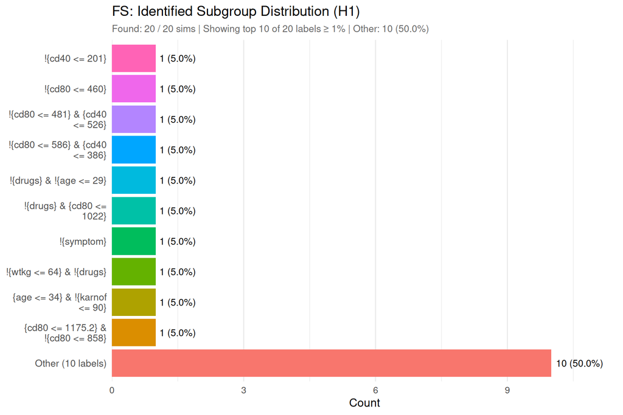

```r
plot_sg_distribution(
  results_alt[results_alt$analysis == "FS", ],
  any_col   = "any.H",
  label_col = "sg.def",
  min_pct   = sgdist_min_pct_alt,
  top_k     = sgdist_top_k,
  title     = "FS: Identified Subgroup Distribution (H1)"
)
```

## 6.5 H1: OR Distribution

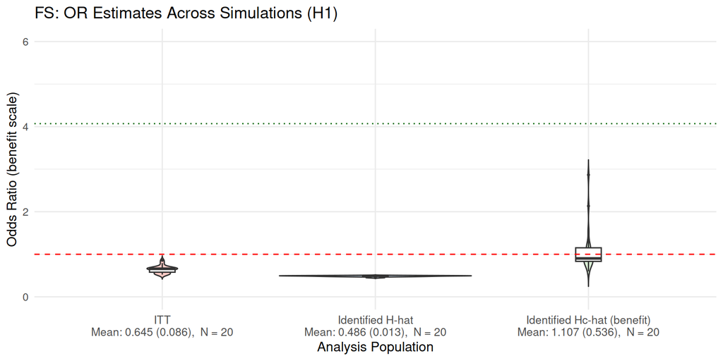

```r
or_Q_true <- dgm_calibrated$hazard_ratios$harm_subgroup

plot_effect_distribution(
  results           = results_alt,
  analysis_method   = "FS",
  effect_measure    = "OR",
  subgroup_notation = sg_notation,
  reference_effect  = or_Q_true,
  ylim              = ordist_ylim,
  title             = "FS: OR Estimates Across Simulations (H1)"
)
```

## 6.6 H0: Type I Error

```r
format_oc_results(
  results_null,
  metrics   = c("detection", "classification"),
  digits    = 2,
  title     = "ACTG175 Binary: Type I Error (Null)",
  subtitle  = sprintf(
    "n = %d, %d sims, OR(ITT) = %.2f",
    sim_n, nsims_null,
    dgm_null$hazard_ratios$overall
  ),
  subgroup_notation = sg_notation
)
```

ACTG175 Binary: Type I Error (Null)

n = 1000, 20 sims, OR(ITT) = 1.52

| Method | Sims | Found | Classification Sen | Classification Spec | Classification PPV | Classification NPV |
| --- | --- | --- | --- | --- | --- | --- |
| FS | 20 | 1.00 | - | 0.48 | 0.00 | 1.00 |
| GRF | 20 | 1.00 | - | 0.22 | 0.00 | 1.00 |

## 6.7 H0: Estimation Tables

```r
build_estimation_table(
  results         = results_null,
  dgm             = dgm_null,
  analysis_method = "FS",
  subgroup_notation = sg_notation,
  title           = "FS: Effect Estimates Under H0"
)
```

FS: Effect Estimates Under H0

FS: 20/20 (100%) estimable

|  | Avg | SD | Min | Max | b† (%) |
| --- | --- | --- | --- | --- | --- |
| Q̂: 20 estimable, avg \|Q̂\| = 518, θ†(Q) = 0.66 |  |  |  |  |  |
| θ̂(Q̂) | 0.49 | 0.01 | 0.45 | 0.50 | -26.06 |
| Q̂ᶜ: avg \|Q̂ᶜ\| = 482, θ†(Qᶜ) = 0.66 |  |  |  |  |  |
| θ̂(Q̂ᶜ) | 1.03 | 0.28 | 0.75 | 2.06 | 55.85 |

θ̂(Q̂) = plugin OR estimate in identified subgroup; θ̂*(Q̂) = bootstrap bias-corrected; b† = bias relative to true OR θ† (causal truth)

```r
build_estimation_table(
  results         = results_null,
  dgm             = dgm_null,
  analysis_method = "GRF",
  subgroup_notation = sg_notation,
  title           = "GRF: Effect Estimates Under H0"
)
```

GRF: Effect Estimates Under H0

GRF: 20/20 (100%) estimable

|  | Avg | SD | Min | Max | b† (%) |
| --- | --- | --- | --- | --- | --- |
| Q̂: 20 estimable, avg \|Q̂\| = 782, θ†(Q) = 0.66 |  |  |  |  |  |
| θ̂(Q̂) | 0.51 | 0.05 | 0.43 | 0.60 | -22.99 |
| Q̂ᶜ: avg \|Q̂ᶜ\| = 218, θ†(Qᶜ) = 0.66 |  |  |  |  |  |
| θ̂(Q̂ᶜ) | 2.38 | 0.91 | 1.49 | 4.22 | 260.97 |

θ̂(Q̂) = plugin OR estimate in identified subgroup; θ̂*(Q̂) = bootstrap bias-corrected; b† = bias relative to true OR θ† (causal truth)

## 6.8 H0: Subgroup Distribution

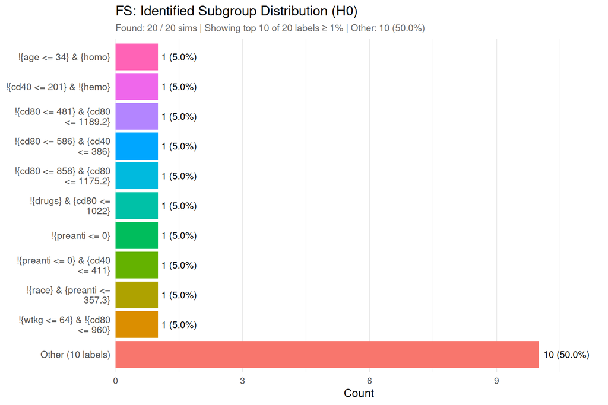

```r
plot_sg_distribution(
  results_null[results_null$analysis == "FS", ],
  any_col   = "any.H",
  label_col = "sg.def",
  min_pct   = sgdist_min_pct_null,
  top_k     = sgdist_top_k,
  title     = "FS: Identified Subgroup Distribution (H0)"
)
```

# 7 Timing

```r
cat(sprintf("H1: %.1f min (%d sims)\n", t_alt / 60, nsims_alt))
```

```
H1: 0.5 min (20 sims)
```

```r
cat(sprintf("H0: %.1f min (%d sims)\n", t_null / 60, nsims_null))
```

```
H0: 0.2 min (20 sims)
```

```r
plan(sequential)
```